# individual2

```r
data(happy, package="productplots")
head(happy)
```

```
##   id         happy year age    sex       marital         degree
## 1  1 not too happy 1972  23 female never married       bachelor
## 2  2 not too happy 1972  70   male       married lt high school
## 3  3  pretty happy 1972  48 female       married    high school
## 4  4 not too happy 1972  27 female       married       bachelor
## 5  5  pretty happy 1972  61 female       married    high school
## 6  6  pretty happy 1972  26   male never married    high school
##         finrela    health wtssall
## 1       average      good  0.4446
## 2 above average      fair  0.8893
## 3       average excellent  0.8893
## 4       average      good  0.8893
## 5 above average      good  0.8893
## 6 above average      good  0.4446
```

```r
HAPPY <- readRDS("HAPPY.rds")
library(plyr)
library(ggmosaic)
library(dplyr)
library(ggthemes)
```

finrela <- Opinion of family income polviews <- Think of self as liberal or conservative wttsall <- weight variable Inapplicable (IAP). Respondents who are not asked to answer a specific question are assigned to IAP.

Answer each of the following questions using R code to get an answer. Write a separate code chunk to manipulate each variable. Once all the data manipulation is done, show the values in a barchart or histogram and comment on the plot. Use ggplot2 to create the plots.

1. Data cleaning: the values “IAP”, “DK” and “NA” all encode missing values. Replace all of these instances by the value NA.

```r
library(dplyr)
library(ggplot2)
HAPPY[HAPPY == "IAP"] <- NA
HAPPY[HAPPY == "DK"] <- NA
HAPPY[HAPPY == "NA"] <- NA
```

2. Check the type of the variable and cast into the right type (factor variable for categorical variables). For age, change “89 OR OLDER” to 89 and assume the variable should be numeric. (Hint: see ?as.character and ?as.numeric)

```r
HAPPY <- HAPPY %>% mutate_if(is.character, as.factor) %>% mutate(AGE = recode(AGE, "89 OR OLDER" = "89")) %>% mutate(AGE = as.numeric(levels(AGE)[AGE]))
str(HAPPY$AGE)
```

```
##  num [1:62466] 23 70 48 27 61 26 28 27 21 30 ...
```

```r
str(HAPPY)
```

```
## 'data.frame':    62466 obs. of  11 variables:
##  $ HAPPY   : Factor w/ 3 levels "NOT TOO HAPPY",..: 1 1 2 1 2 2 1 1 2 2 ...
##  $ YEAR    : int  1972 1972 1972 1972 1972 1972 1972 1972 1972 1972 ...
##  $ AGE     : num  23 70 48 27 61 26 28 27 21 30 ...
##  $ SEX     : Factor w/ 2 levels "FEMALE","MALE": 1 2 1 1 1 2 2 2 1 1 ...
##  $ MARITAL : Factor w/ 5 levels "DIVORCED","MARRIED",..: 3 2 2 2 2 3 1 3 3 2 ...
##  $ DEGREE  : Factor w/ 5 levels "BACHELOR","GRADUATE",..: 1 5 3 1 3 3 3 1 3 3 ...
##  $ FINRELA : Factor w/ 5 levels "ABOVE AVERAGE",..: 2 1 2 2 1 1 1 2 2 3 ...
##  $ HEALTH  : Factor w/ 4 levels "EXCELLENT","FAIR",..: 3 2 1 3 3 3 1 3 1 2 ...
##  $ WTSSALL : num  0.445 0.889 0.889 0.889 0.889 ...
##  $ PARTYID : Factor w/ 8 levels "IND,NEAR DEM",..: 1 4 3 4 7 1 1 1 7 7 ...
##  $ POLVIEWS: Factor w/ 7 levels "CONSERVATIVE",..: NA NA NA NA NA NA NA NA NA NA ...
```

3. Bring all levels of factors into a sensible order. For marital you could e.g. order the levels according to average age.

```r
HAPPY <- HAPPY %>% mutate(MARITAL = factor(MARITAL, levels = c("NEVER MARRIED", "MARRIED", "SEPARATED", "DIVORCED", "WIDOWED"))) %>% arrange(desc(MARITAL))

 HAPPY <- HAPPY %>% mutate( HAPPY= factor(HAPPY, levels = c("NOT TOO HAPPY", "PRETTY HAPPY", "VERY HAPPY"))) %>% arrange(desc(HAPPY))

HAPPY <- HAPPY %>%
  mutate( DEGREE= factor(DEGREE,
                          levels = c("LT HIGH SCHOOL", "HIGH SCHOOL", "JUNIOR COLLEGE", "BACHELOR", "GRADUATE"))) %>% arrange(desc(DEGREE))

HAPPY <- HAPPY %>%
  mutate( FINRELA= factor(FINRELA,
                          levels = c("FAR BELOW AVERAGE", "BELOW AVERAGE", "AVERAGE", "ABOVE AVERAGE", "FAR ABOVE AVERAGE"))) %>%
  arrange(desc(FINRELA))

HAPPY <- HAPPY %>%
  mutate( HEALTH= factor(HEALTH,
                          levels = c("POOR ", "FAIR", "GOOD", "EXCELLENT"))) %>% arrange(desc(HEALTH))

HAPPY <- HAPPY %>%
  mutate( PARTYID= factor(PARTYID,
                          levels = c("STRONG DEMOCRAT", "NOT STR DEMOCRAT", "IND,NEAR DEM", "INDEPENDENT", "IND,NEAR REP", "NOT STR REPUBLICAN","STRONG REPUBLICAN", "OTHER PARTY"))) %>% arrange(desc(PARTYID))

HAPPY <- HAPPY %>%
  mutate( POLVIEWS= factor(POLVIEWS,
                          levels = c("EXTREMELY LIBERAL", "LIBERAL", "SLIGHTLY LIBERAL", "MODERATE", "SLIGHTLY CONSERVATIVE", "CONSERVATIVE","EXTRMELY CONSERVATIVE"))) %>% arrange(desc(POLVIEWS))
levels(HAPPY$POLVIEWS)
```

```
## [1] "EXTREMELY LIBERAL"     "LIBERAL"               "SLIGHTLY LIBERAL"
## [4] "MODERATE"              "SLIGHTLY CONSERVATIVE" "CONSERVATIVE"
## [7] "EXTRMELY CONSERVATIVE"
```

Part 2 Happiness! Use ggplot2 to create the plots. Your exploration should make use all elements of the grammar of graphics: mappings (color, fill, and size at least), different geoms (4 at least), scales, coordinates (eg coord_flip), facet, and theme (eg setting axis labels and title). For each investigation, create an appropriate visualization and write a paragraph to describe it.

1. Investigate the distributions of 2 different variables.

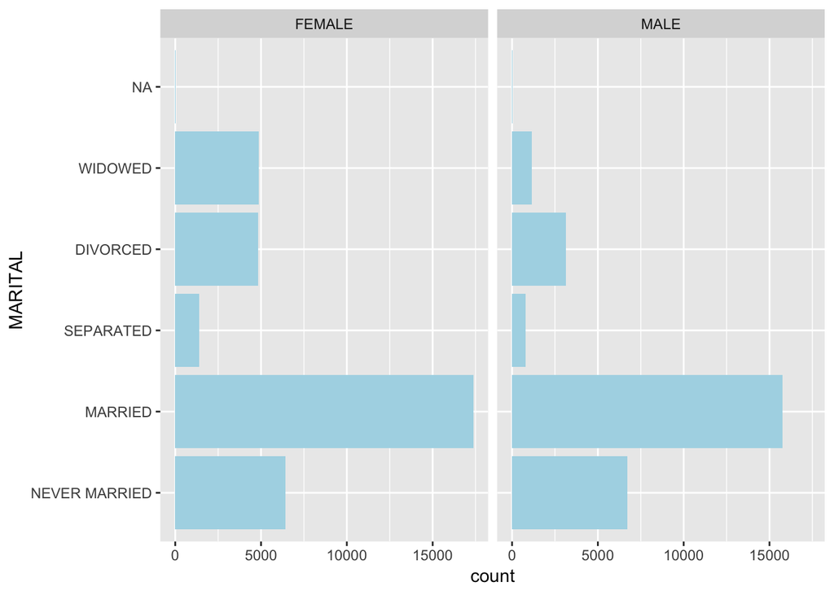

```r
ggplot(data=HAPPY,aes(x=MARITAL))+ geom_bar(fill="lightblue") + facet_wrap(~SEX) + coord_flip()
```

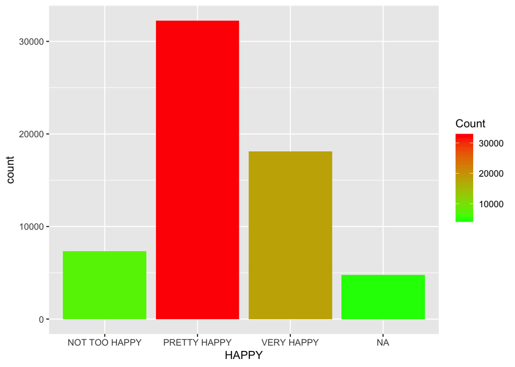

```r
ggplot(HAPPY, aes(x= HAPPY)) + geom_bar( aes(fill=..count..)) + scale_fill_gradient("Count", low="green", high ="red")
```

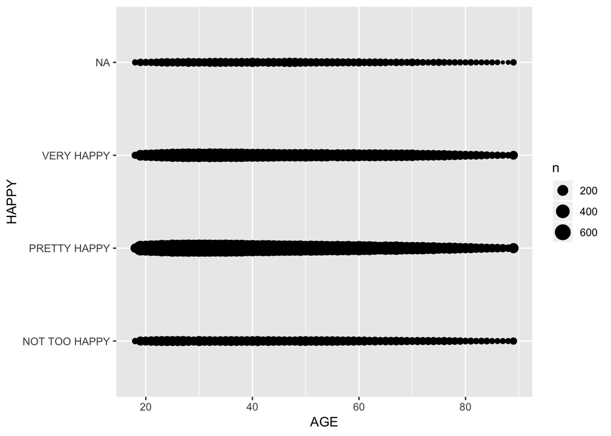

```r
ggplot(HAPPY, aes(x=AGE, y=HAPPY)) + geom_count()
```

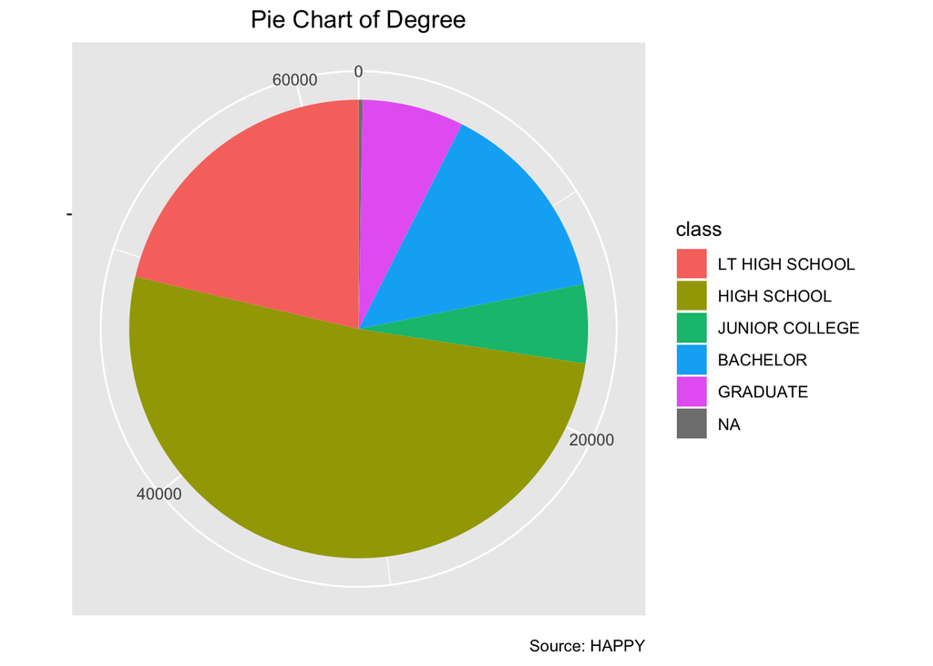

```r
pie <- ggplot(HAPPY, aes(x = "", fill = factor(DEGREE ))) +
  geom_bar(width = 1) +
  theme(axis.line = element_blank(),
        plot.title = element_text(hjust=0.5)) +
  labs(fill="class",
       x=NULL,
       y=NULL,
       title="Pie Chart of Degree",
       caption="Source: HAPPY")

pie + coord_polar(theta = "y", start=0)
```

```r
#This pie chart is weird, it shows that more than half of the people in this data set have a highschool degree, and the average age is above 25, meaning most people in this study didnt go to college, and probably arent planning on it.
```

2. Investigate the relationship between happiness and three other variables in the data.

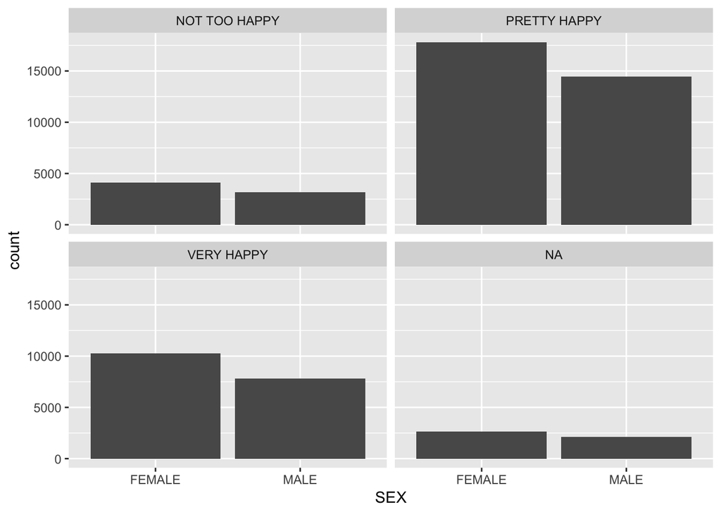

```r
ggplot(HAPPY, aes(x=SEX)) +geom_bar() + facet_wrap(~HAPPY)
```